# ggplot2のすゝめ

## 2.14 軸の比率を変更する

座標軸の範囲はデータに応じて自動的に決まりますが、ｘ軸とｙ軸の比率を変更することで見やすい、理解しやすいグラフになることがあります。このような場合には`ggplot2::coord_fixed`関数を用います。

```r
# Usage
coord_fixed(ratio = 1, xlim = NULL, ylim = NULL, expand = TRUE)
```

`ggplot2::coord_equal`関数というのもありますが、これは`ggplot2::coord_fixed`関数のエイリアス関数です。では、座標軸の比率を１（デフォルト値）に設定してみましょう。

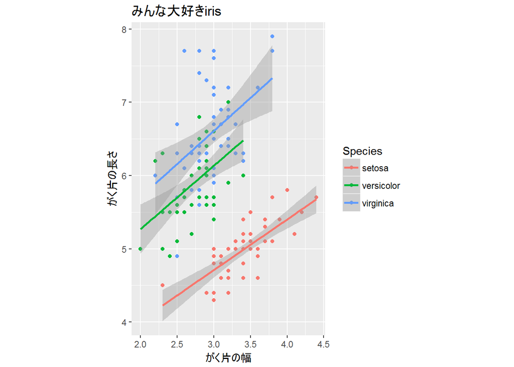

```r
iris %>%
  ggplot2::ggplot(ggplot2::aes(x = Sepal.Width, y = Sepal.Length,
                               colour = Species)) +
    ggplot2::geom_point() +
    ggplot2::ggtitle("みんな大好きiris") +
    ggplot2::xlab("がく片の幅") + ggplot2::ylab("がく片の長さ") +
    ggplot2::geom_smooth(method = "lm", se = TRUE) +
    ggplot2::coord_fixed()
```

## 2.15 対数軸を用いる

対数軸グラフを描く場合は`ggplot2::cord_trans`関数または`ggplot2::scale_x_log10`、`ggplot2::scale_y_log10`両関数がありますが対数軸以外も描画可能な`ggplot2::cord_trans`関数を使うのがおすゝめです。

```r
# Usage
coord_trans(x = "identity", y = "identity", limx = NULL, limy = NULL,
            xtrans, ytrans)
```

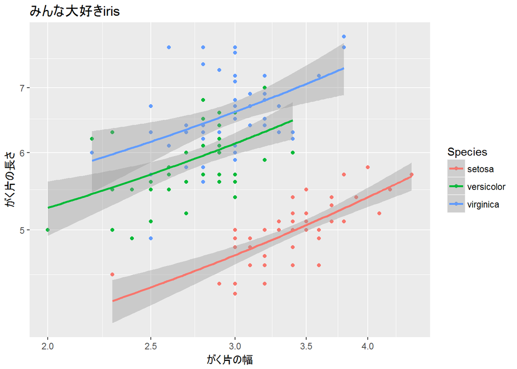

```r
iris %>%
  ggplot2::ggplot(ggplot2::aes(x = Sepal.Width, y = Sepal.Length,
                               colour = Species)) +
    ggplot2::geom_point() +
    ggplot2::ggtitle("みんな大好きiris") +
    ggplot2::xlab("がく片の幅") + ggplot2::ylab("がく片の長さ") +
    ggplot2::geom_smooth(method = "lm", se = TRUE) +
    ggplot2::coord_trans(x = "log", y = "log")
```

## 2.16 軸を入れ替る

`ggplot2::coord_`関数群を用いるとデータを変更することなく軸の操作が可能です。横軸と縦軸を入れ替えるには`ggplot2::coord_flip`関数を用います。

```r
# Usage
coord_flip(xlim = NULL, ylim = NULL, expand = TRUE)
```

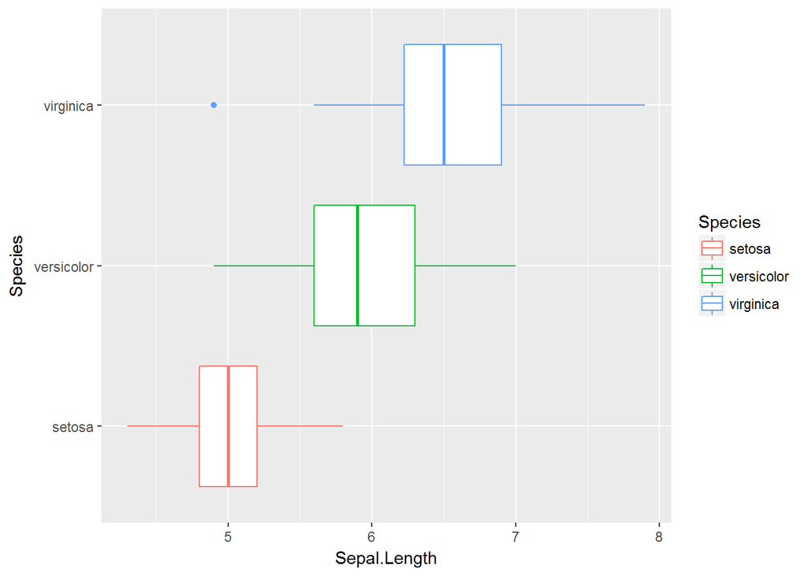

```r
iris %>%
  ggplot2::ggplot(ggplot2::aes(x = Species, y = Sepal.Length,
                               colour = Species)) +
    ggplot2::geom_boxplot() +
    ggplot2::coord_flip()
```

## 2.17 軸の反転

軸を反転させるには`ggplot2::scale_x_reverse`、`ggplot2::scale_y_reverse`関数を用います。

```r
# Usage
scale_x_continuous(name = waiver(), breaks = waiver(), minor_breaks = waiver(),
                   labels = waiver(), limits = NULL, expand = waiver(),
                   oob = censor, na.value = NA_real_, trans = "identity",
                   position = "bottom", sec.axis = waiver())

scale_y_continuous(name = waiver(), breaks = waiver(), minor_breaks = waiver(),
                   labels = waiver(), limits = NULL, expand = waiver(),
                   oob = censor, na.value = NA_real_, trans = "identity",
                   position = "left", sec.axis = waiver())
```

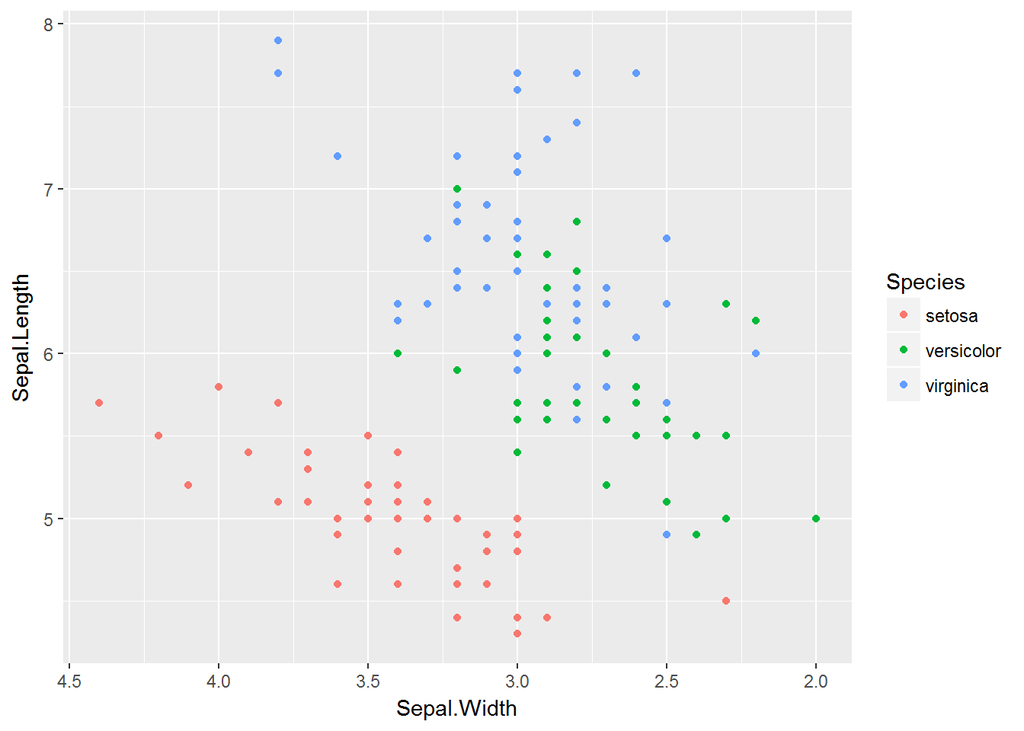

```r
iris %>%
  ggplot2::ggplot(ggplot2::aes(x = Sepal.Width, y = Sepal.Length,
                               colour = Species)) +
    ggplot2::geom_point() +
    ggplot2::scale_x_reverse()
```

## 2.18 テキストラベルをつける

個々のデータにテキストラベルを付与することも可能ですが、データ数が多かったりデータの値が近接していたりすると逆に見難くなってしまうというデメリットもあります。テキストやラベルを表示するには`ggplot2::geom_text`関数または`ggplot2::geom_label`関数を用います。

```r
# Usage
geom_label(mapping = NULL, data = NULL, stat = "identity",
           position = "identity", ..., parse = FALSE, nudge_x = 0, nudge_y = 0,
           label.padding = unit(0.25, "lines"), label.r = unit(0.15, "lines"),
           label.size = 0.25, na.rm = FALSE, show.legend = NA,
           inherit.aes = TRUE)

geom_text(mapping = NULL, data = NULL, stat = "identity",
          position = "identity", ..., parse = FALSE, nudge_x = 0, nudge_y = 0,
          check_overlap = FALSE, na.rm = FALSE, show.legend = NA,
          inherit.aes = TRUE)
```

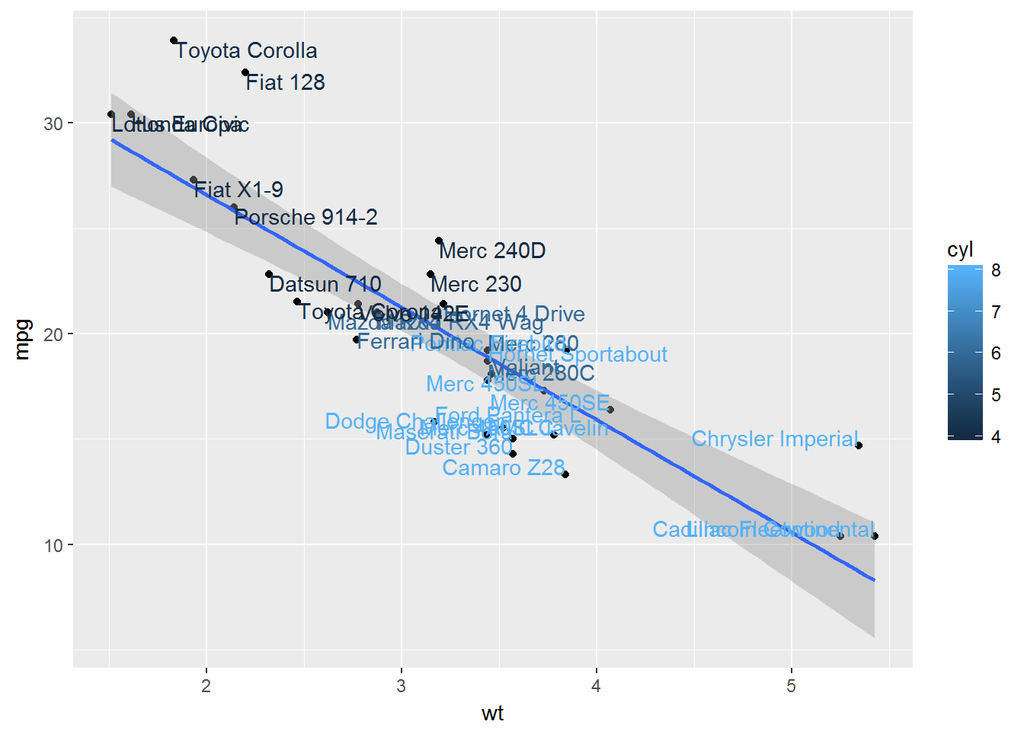

```r
mtcars %>%
  ggplot2::ggplot(ggplot2::aes(x = wt, y = mpg)) +
    ggplot2::geom_point() +
    ggplot2::geom_smooth(method = "lm") +
    ggplot2::geom_text(ggplot2::aes(label = row.names(.), colour = cyl),
                       hjust = "inward", vjust = "inward")
```

## 2.19 統計情報で描く

```r
# Usage
stat_summary(mapping = NULL, data = NULL, geom = "pointrange",
             position = "identity", ..., fun.data = NULL, fun.y = NULL,
             fun.ymax = NULL, fun.ymin = NULL, fun.args = list(), na.rm = FALSE,
             show.legend = NA, inherit.aes = TRUE)
```

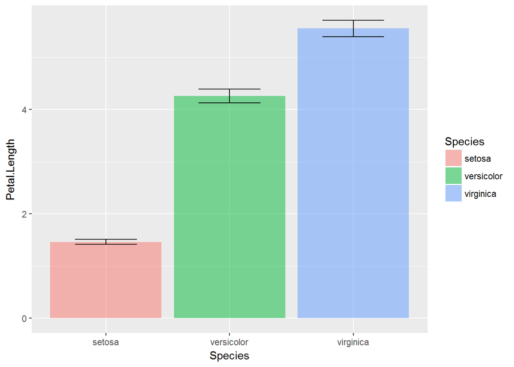

```r
iris %>%
  ggplot2::ggplot(ggplot2::aes(x = Species, y = Petal.Length,
                               fill = Species)) +
    ggplot2::stat_summary(fun.y = mean, geom = "bar", alpha = 0.5) +
    ggplot2::stat_summary(fun.data = mean_cl_normal, geom = "errorbar",
                          width = 0.5)
```

## 2.20 層別に描く

見やすくするために種別（`Species`）のデータを用いて層別のグラフにしてみましょう。層別に描くには`ggplot2::facet_warp`を用います。

```r
# Usage
facet_wrap(facets, nrow = NULL, ncol = NULL, scales = "fixed", shrink = TRUE,
           labeller = "label_value", as.table = TRUE, switch = NULL,
           drop = TRUE, dir = "h", strip.position = "top")
```

引数`facets`は下記のようにformula形式で指定することに注意して下さい。

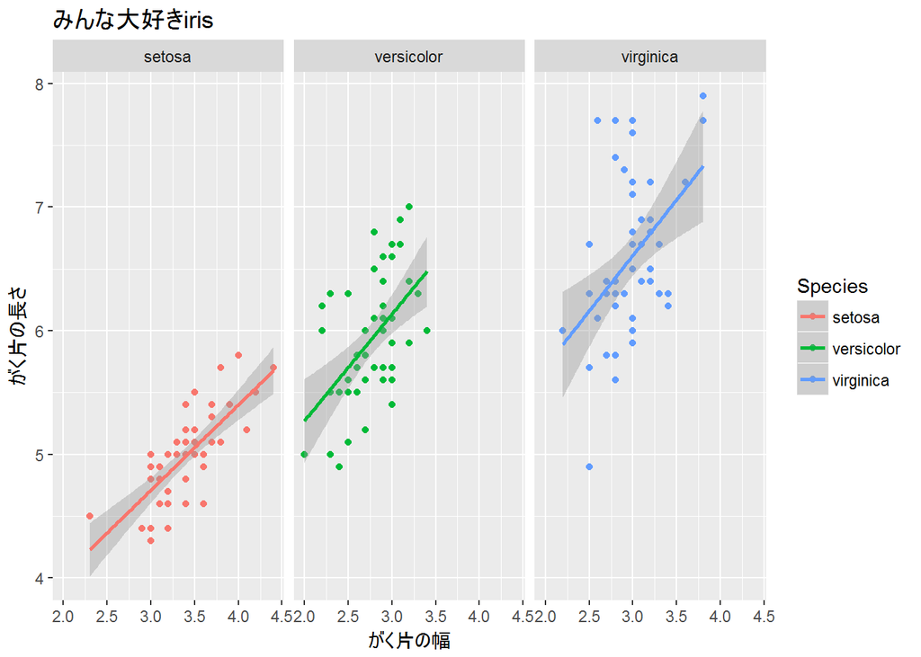

```r
iris %>%
  ggplot2::ggplot(ggplot2::aes(x = Sepal.Width, y = Sepal.Length,
                               colour = Species)) +
    ggplot2::geom_point() +
    ggplot2::ggtitle("みんな大好きiris") +
    ggplot2::xlab("がく片の幅") + ggplot2::ylab("がく片の長さ") +
    ggplot2::geom_smooth(method = "lm", se = TRUE) +
    ggplot2::facet_wrap(~ Species)
```

## 2.21 二変数で層別に描く

二変数でマトリクス状に層別にしたい場合は`ggplot2::facet_grid`関数を用います。`mtcars`データセットを用いて車重（`wt`）と燃費（`mpg`）の関係をシリンダ数（`cyl`）とギア数（`gear`）で層別表示してみます。

```r
# Usage
facet_grid(facets, margins = FALSE, scales = "fixed", space = "fixed",
           shrink = TRUE, labeller = "label_value", as.table = TRUE,
           switch = NULL, drop = TRUE)
```

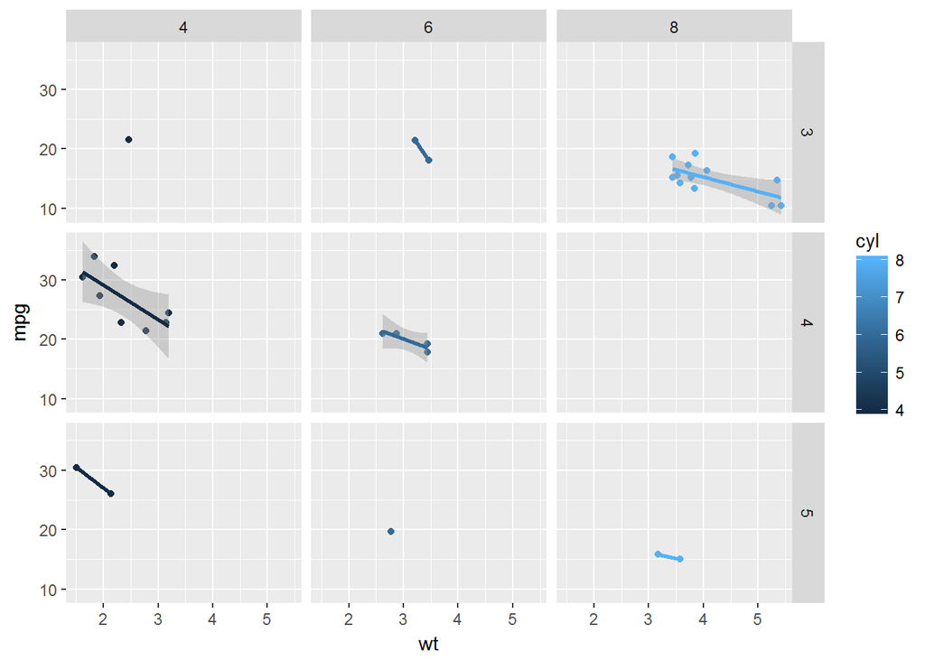

```r
mtcars %>%
  ggplot2::ggplot(ggplot2::aes(x = wt, y = mpg, colour = cyl)) +
    ggplot2::geom_point() +
    ggplot2::geom_smooth(method = "lm", se = TRUE) +
    ggplot2::facet_grid(gear ~ cyl)
```

# 3 まとめ

このように`ggplot2`パッケージでは統一的な文法によりどのようなグラフも同じように描けることが分かります。加えて、色指定やグラフ装飾等も標準のグラフに比べるとてリッチです。まさに“ggplot2: Elegant Graphics for Data Analysis”。積極的に使ってみて下さい。  
紹介した以外にも`ggplot2`パッケージは時系列の折れ線グラフや棒グラフなど、様々なグラフを描くことが可能です。どのようなグラフを描けるかはヘルプはインターネットで調べてみてください。

## 3.1 ggplot2::aes関数のオプション

`ggplot2`を理解するコツの一つに`ggplot2::aes`関数でのオプション指定があります。

| 指定内容 | オプション | 指定方法例 | 備考 |
| --- | --- | --- | --- |
| 座標軸の指定 | x, y, z | aes(x = Petal.Length, y = Petal.Width) | zは3次元の場合 |
| 色の指定 | colour | aes(colour = Species) | 描画線のみ |
| 塗りつぶ色の指定 | fill | aes(fill = Species) |  |
| シンボルの指定 | shape | aes(shape = Species) |  |
| サイズの指定 | size | aes(size = Species) |  |
| 線種の指定 | linetype | aes(linetype = Species) |  |
| 透過度の指定 | alpha |  |  |

[CC BY-NC-SA 4.0](http://creativecommons.org/licenses/by-nc-sa/4.0/deed.ja), Sampo Suzuki [2017-07-31 17:33(JST)]